# Analyses

KN

2022-11-15

For output from ibex farm

# About

- SPR conducted at Lancers ibex, May 8, 2018
- 116 participants
- Target items: 24
- Filler items: 48

Conditions:  
Ds. Durative × Simplex  
Dr. Durative x Reduplicated  
Cs. Non-durative x Simplex  
Cr. Non-durative x Reduplicated

[[“Ds”,1], “DashedSentenceNoSpace”,  
{s: “生徒が しばらく 黒板を ちらっと 見たので 先生が カンニングを 疑った。”},  
“Question”, {q: “生徒は黒板をしばらく見た。”, hasCorrect:0}], [[“Dr”,1], “DashedSentenceNoSpace”,  
{s: “生徒が しばらく 黒板を ちらちら 見たので 先生が カンニングを 疑った。”}, “Question”,  
{q: “生徒は黒板をしばらく見た。”, hasCorrect:0}], [[“Cs”,1], “DashedSentenceNoSpace”,  
{s: “生徒が その時 黒板を ちらっと 見たので 先生が カンニングを 疑った。”},  
“Question”, {q: “生徒は黒板をしばらく見た。”, hasCorrect:1}], [[“Cr”,1], “DashedSentenceNoSpace”,  
{s: “生徒が その時 黒板を ちらちら 見たので 先生が カンニングを 疑った。”},  
“Question”, {q: “生徒は黒板をしばらく見た。”, hasCorrect:1}],

##### Load libraries

```r
#library(lme4)
library(lmerTest)
library(plyr)
library(dplyr)
```

```r
library(ggplot2)
library(reshape)
library(gdata)
library(MASS)
```

##### Declare the expt name that is relevant.

```r
ex<-"e"

# critical region
criticalregion<-4

# how far from the critical region do you want the plot to cover?
crplus<-3

# plot legend（凡例）のならび順はデフォルトではアルファベット順
# 逆順にしたい場合はここを1にする
revorderA <- 1  # ab vs cd
revorderB <- 1  # ac vs bd
```

##### Load data:

```r
alldata<-read.csv("alldata.csv",header=T)
alldata<-alldata[,-1]
alldata$item<-as.numeric(alldata$item)
itemdata<-read.csv("itemdata.csv")
itemdata<-itemdata[,-1]
# 標準化（z値化）
# 注：scale()[,1]としているのは，scale()は行列を返すので，「列1だけ出力おねがい」という意味
itemdata$Itemvalue<-scale(itemdata$Itemvalue, center = T, scale = T)[,1]
alldata <- merge(alldata,itemdata,all=T);
```

# Isolate the data from the relevant experiment

```r
data<-subset(alldata,expt==ex)
unique(data$expt)
```

```
## [1] "e"
```

# Subj exclusion

##### before trimming

Subject number before trimming

```r
unique(data$subj)
```

```
##   [1]  95  43  39  65  91  62  75  69  67  68  45  74  20  66  92  22  40  97
##  [19] 102  98 100  93  89  77  71  47  44  18  73  72  99  90  48 101  12  94
##  [37]  42  14  46  16  88  37  38  10  51  96  63  36  76  41  24  70 106 115
##  [55]   8  19 103  35  17  26  34  61  64 116 112  15   6 104 105  28  53   4
##  [73] 114  33  31  13 109  59  60  86  57  11  49  78  80 108  55   2  32  58
##  [91] 113  87   9  82  30 110 111  85   7  25  54  56   5  23  52 107  81  29
## [109]  83  84   3  21  50  79  27   1
```

```r
length(unique(data$subj))
```

```
## [1] 116
```

##### trim by CA

```r
data<-subset(data,SubjCA>=200/3)
unique(data$subj)
```

```
##   [1]  95  43  39  65  91  62  75  69  67  68  45  74  20  66  92  22  40  97
##  [19] 102  98 100  93  89  77  71  47  44  18  73  72  99  90  48  12  94  42
##  [37]  14  46  16  88  37  38  10  51  96  63  36  76  41  70 106   8  19 103
##  [55]  35  26  34  61  64 116 112  15   6 104 105  28  53   4 114  33  31  13
##  [73] 109  59  60  86  57  11  49  78  80 108  55   2  32  58 113  87   9  82
##  [91]  30 111  85   7  25  54  56   5  23  52 107  81  29  83  84   3  21  50
## [109]  79  27   1
```

```r
length(unique(data$subj))
```

```
## [1] 111
```

##### trim by RTZS

```r
data<-subset(data,SubjRTZS<=3)
unique(data$subj)
```

```
##   [1]  95  43  39  65  91  62  75  69  67  68  45  74  20  66  92  22  40  97
##  [19] 102  98 100  93  89  77  71  47  44  18  72  99  90  48  12  94  42  14
##  [37]  46  16  88  37  38  10  51  96  63  36  76  41  70 106   8  19 103  35
##  [55]  26  34  61  64 116 112  15   6 104 105  28  53   4 114  33  31  13 109
##  [73]  59  60  86  57  11  49  78  80 108  55   2  32  58 113  87   9  82  30
##  [91] 111  85   7  25  54  56   5  23  52 107  81  29  83  84   3  21  50  79
## [109]  27   1
```

```r
length(unique(data$subj))
```

```
## [1] 110
```

##### trim by RTmean

```r
data<-subset(data,SubjRTmean<=10000)
unique(data$subj)
```

```
##   [1]  95  43  39  65  91  62  75  69  67  68  45  74  20  66  92  22  40  97
##  [19] 102  98 100  93  89  77  71  47  44  18  72  99  90  48  12  94  42  14
##  [37]  46  16  88  37  38  10  51  96  63  36  76  41  70 106   8  19 103  35
##  [55]  26  34  61  64 116 112  15   6 104 105  28  53   4 114  33  31  13 109
##  [73]  59  60  86  57  11  49  78  80 108  55   2  32  58 113  87   9  82  30
##  [91] 111  85   7  25  54  56   5  23  52 107  81  29  83  84   3  21  50  79
## [109]  27   1
```

```r
length(unique(data$subj))
```

```
## [1] 110
```

# Reading time summary

```r
rt_data<-data
```

##### Make sure factors are treated as factors

```r
rt_data$subj<-factor(rt_data$subj)
rt_data$expt<-factor(rt_data$expt)
rt_data$item<-factor(rt_data$item)
rt_data$cond<-factor(rt_data$cond)
rt_data$word<-factor(rt_data$word)
```

##### Correctly answered trials only? (trimincorrect)

Note: if you do this trimming at this point, it precedes the z-score computation.

```r
  rt_data<-subset(rt_data,correct==100)
```

rt trimming

```r
rt_data_notrim <- rt_data

rt_data<-subset(rt_data_notrim,rt>=150 & rt<=10000)
```

Generate z-scores for variable A using the scale() function scale(A, center = TRUE, scale = TRUE)

```r
myRT <- c()
newdataframe <- c()
for(i in unique(rt_data$region)){
  for(j in unique(rt_data$cond)){
    # abstract rt column in the region x cond cell
    myRT <- subset(rt_data, region==i & cond==j);
    # compute z-score; [,1]を付けるのはscale()が行列データを返すので列1だけ出力してという意味
    myRT$RxCzs <- scale(myRT$rt, center = T, scale = T)[,1];
    # 蓄積
    newdataframe<-rbind(newdataframe,myRT);
    }
};

rt_data <- merge(rt_data,newdataframe,all=T)
length(unique(rt_data$subj))
```

```
## [1] 110
```

##### rt trimming based on RxCzs

```r
tapply(rt_data$rt, paste(rt_data$region, rt_data$cond), mean)
```

```
##     1 Cr     1 Cs     1 Dr     1 Ds     2 Cr     2 Cs     2 Dr     2 Ds
## 740.1060 735.1942 725.1374 706.4840 582.3014 603.0701 582.7443 598.6959
##     3 Cr     3 Cs     3 Dr     3 Ds     4 Cr     4 Cs     4 Dr     4 Ds
## 609.8460 598.0359 595.3930 613.4789 585.0639 596.1095 594.1235 613.9511
##     5 Cr     5 Cs     5 Dr     5 Ds     6 Cr     6 Cs     6 Dr     6 Ds
## 641.1657 642.5189 646.3757 738.0354 583.7425 589.9964 594.8348 609.6374
##     7 Cr     7 Cs     7 Dr     7 Ds     8 Cr     8 Cs     8 Dr     8 Ds
## 555.4212 544.7989 558.6678 553.3706 642.2375 685.4004 650.1899 646.0067
```

```r
rt_data<-subset(rt_data,RxCzs<3)

tapply(rt_data$rt, paste(rt_data$region, rt_data$cond), mean)
```

```
##     1 Cr     1 Cs     1 Dr     1 Ds     2 Cr     2 Cs     2 Dr     2 Ds
## 698.1951 698.6728 691.8103 668.0000 562.2637 583.0200 554.3020 578.6809
##     3 Cr     3 Cs     3 Dr     3 Ds     4 Cr     4 Cs     4 Dr     4 Ds
## 582.2500 563.4936 560.4484 592.6153 550.1609 566.3315 561.9523 580.2547
##     5 Cr     5 Cs     5 Dr     5 Ds     6 Cr     6 Cs     6 Dr     6 Ds
## 593.6260 604.6905 596.9520 663.8542 557.1609 566.0606 576.1711 589.3373
##     7 Cr     7 Cs     7 Dr     7 Ds     8 Cr     8 Cs     8 Dr     8 Ds
## 531.3885 523.6892 538.0901 537.5395 614.3684 634.0111 621.7496 616.5439
```

```r
mean(subset(rt_data,region==5&cond=="h")$rt)
```

```
## [1] NaN
```

```r
(length(rt_data_notrim$rt)-length(rt_data$rt))*100/length(rt_data_notrim$rt)
```

```
## [1] 1.808176
```

```r
tapply(rt_data$rt, paste(rt_data$region, rt_data$cond), mean)
```

```
##     1 Cr     1 Cs     1 Dr     1 Ds     2 Cr     2 Cs     2 Dr     2 Ds
## 698.1951 698.6728 691.8103 668.0000 562.2637 583.0200 554.3020 578.6809
##     3 Cr     3 Cs     3 Dr     3 Ds     4 Cr     4 Cs     4 Dr     4 Ds
## 582.2500 563.4936 560.4484 592.6153 550.1609 566.3315 561.9523 580.2547
##     5 Cr     5 Cs     5 Dr     5 Ds     6 Cr     6 Cs     6 Dr     6 Ds
## 593.6260 604.6905 596.9520 663.8542 557.1609 566.0606 576.1711 589.3373
##     7 Cr     7 Cs     7 Dr     7 Ds     8 Cr     8 Cs     8 Dr     8 Ds
## 531.3885 523.6892 538.0901 537.5395 614.3684 634.0111 621.7496 616.5439
```

```r
RTlabel<-"RTs(ms)"
```

```r
# First, change the value of spilloverraw under lowerboundRT to the value of lowerboundRT because we do not overestimate the negative spillover effects
rt_data$spilloverraw[rt_data$spilloverraw<150]<-150

rt_data$spillover<-scale(rt_data$spilloverraw, center=T, scale=T)
```

## Summary (interim)

のちにtrimmingをする（かもしれない）ので，このファイルの最後でもういちどサマリーとプロットの最終盤を生成します。

##### Extract data for summary

###### Critical region plus 3

```r
rtg <- subset(rt_data,region<=criticalregion+crplus)
```

##### summary

```r
rt_data_summary <- ddply(rtg, .(cond,region), summarise, N=length(rt), mean=mean(rt), sd=sd(rt), se=sd/sqrt(N),ci=qt(0.975,df=N-1)*se)
```

##### Coding conditions for plot labels

```r
rt_data_summary$A<-ifelse(rt_data_summary$cond%in%c("Cr","Cs"),"Non-durative","Durative")
rt_data_summary$B<-ifelse(rt_data_summary$cond%in%c("Cr","Dr"),"Reduplicated","Simplex")
rt_data_summary$Conditions<-paste(rt_data_summary$A,rt_data_summary$B,sep=":")
rt_data_summary$B
```

```
##  [1] "Reduplicated" "Reduplicated" "Reduplicated" "Reduplicated" "Reduplicated"
##  [6] "Reduplicated" "Reduplicated" "Simplex"      "Simplex"      "Simplex"
## [11] "Simplex"      "Simplex"      "Simplex"      "Simplex"      "Reduplicated"
## [16] "Reduplicated" "Reduplicated" "Reduplicated" "Reduplicated" "Reduplicated"
## [21] "Reduplicated" "Simplex"      "Simplex"      "Simplex"      "Simplex"
## [26] "Simplex"      "Simplex"      "Simplex"
```

```r
# Change the order of the legend labels
if( revorderA == 1 ){
  rt_data_summary$A<-factor(rt_data_summary$A, levels=rev(levels(factor(rt_data_summary$A))))}
if( revorderB == 1 ){
  rt_data_summary$B<-factor(rt_data_summary$B, levels=rev(levels(factor(rt_data_summary$B))))
}


# Factor labels in the plots
Alabel<-"Temp Adverb"
Blabel<-"Onomatopoeia"

rt_data_summary
```

```
##    cond region   N     mean       sd        se       ci            A
## 1    Cr      1 492 698.1951 357.8417 16.132748 31.69774 Non-durative
## 2    Cr      2 493 562.2637 238.0706 10.722161 21.06687 Non-durative
## 3    Cr      3 492 582.2500 280.8199 12.660338 24.87512 Non-durative
## 4    Cr      4 491 550.1609 232.9950 10.514919 20.65989 Non-durative
## 5    Cr      5 492 593.6260 310.0387 13.977623 27.46333 Non-durative
## 6    Cr      6 491 557.1609 222.2307 10.029132 19.70541 Non-durative
## 7    Cr      7 489 531.3885 187.7611  8.490852 16.68314 Non-durative
## 8    Cs      1 547 698.6728 332.5380 14.218299 27.92927 Non-durative
## 9    Cs      2 551 583.0200 263.1054 11.208669 22.01704 Non-durative
## 10   Cs      3 543 563.4936 257.8861 11.066953 21.73938 Non-durative
## 11   Cs      4 549 566.3315 264.8243 11.302426 22.20138 Non-durative
## 12   Cs      5 546 604.6905 306.7969 13.129695 25.79100 Non-durative
## 13   Cs      6 545 566.0606 225.6400  9.665355 18.98599 Non-durative
## 14   Cs      7 547 523.6892 177.8402  7.603899 14.93648 Non-durative
```

[output cut: 43 more lines]

```r
#rrt_data_summary
```

## Plots

See the following references for ggplot codes:

http://www.cookbook-r.com/Graphs/Shapes_and_line_types/

http://meme.biology.tohoku.ac.jp/students/iwasaki/rstats/ggplot2.html

##### Mean RTs

Base

```r
g <- ggplot(rt_data_summary,aes(x=region,y=mean,group=Conditions))
```

Add lines

```r
g <- g + geom_line(size=1,aes(linetype=A))
g <- g + scale_linetype_manual(values=c("dotdash","solid"))
g <- g + labs(linetype=Alabel)
```

Add points

```r
g <- g + geom_point(size=5,aes(shape=B,fill=B))
g <- g + scale_shape_manual(values=c(21,24,24,25))
g <- g + scale_fill_manual(values=c("white","black","white","black"))
g <- g + labs(shape=Blabel)
g <- g + labs(fill=Blabel)
```

Add error bars

```r
g <- g + geom_errorbar(aes(ymin=mean-se, ymax=mean+se), width=.3)
```

Adjust x-axis breaks and labels

```r
g <- g + scale_x_continuous(breaks=seq(1, 8, by=1),labels=c("Subj", "Temp Adv",
                              "Mod", "Onom", "Verb", "6","7","8"))
```

Create Theme

```r
g <- g + theme(
                 # 背景を消す
                 panel.background = element_rect(fill = "white"),
                 panel.border = element_blank(), axis.line = element_line(),
                 # 凡例の設定
                 legend.position    = c(1, 1),
                 legend.justification = c(1,1),
                 #legend.title = element_blank(),
                 legend.title = element_text(family = "Times", size = 15),
                 legend.text = element_text(size = 15, family="Times"),
                 legend.key = element_blank(),
                 # テキスト形式の設定
                 axis.title.x = element_text(family = "Times", size = 20),
                 axis.title.y = element_text(family = "Times",size = 20),
                 axis.text.x = element_text(angle =   45, size = 15, hjust = 1,family = "Times"),
                 axis.text.y = element_text(size = 15, hjust = 0.5, family = "Times"),
              )
```

Adjust appearance

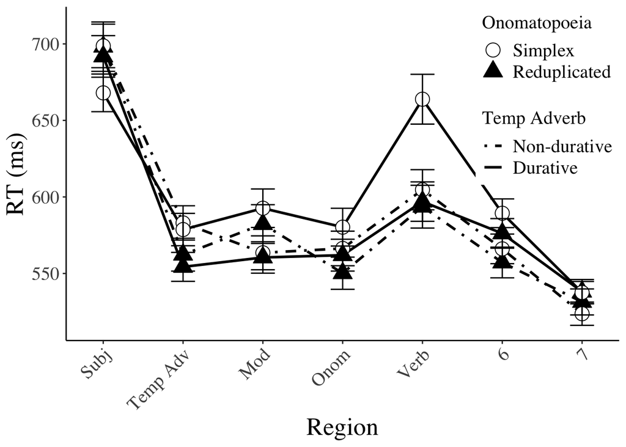

```r
#g <- g + theme_classic(base_size=20, base_family="HiraKakuProN-W3")
#g <- g + theme(base_size=20, base_family="Times", axis.text.x = element_text(angle = 45, hjust = 1))
g <- g + labs(x="Region", y="RT (ms)")
print(g)
```

##### Interaction

Base

```r
rtg <- subset(rt_data_summary,region==criticalregion)
g <- ggplot(rtg,aes(x=A,y=mean,group=Conditions))
```

Add lines

```r
g <- g + geom_line(size=1,aes(group=B,linetype=B))
g <- g + scale_linetype_manual(values=c("dotdash","solid"))
g <- g + labs(linetype=Blabel)
```

Add points

```r
g <- g + geom_point(size=8,aes(shape=B,fill=B))
g <- g + scale_shape_manual(values=c(21,24,24,25))
g <- g + scale_fill_manual(values=c("white","black","white","black"))
g <- g + labs(shape=Blabel)
g <- g + labs(fill=Blabel)
```

Add error bars

```r
g <- g + geom_errorbar(aes(ymin=mean-ci, ymax=mean+ci), width=.1)
```

Adjust x-axis breaks

```r
#g <- g + scale_x_continuous(breaks=seq(1, 10, by=1))
```

Adjust appearance

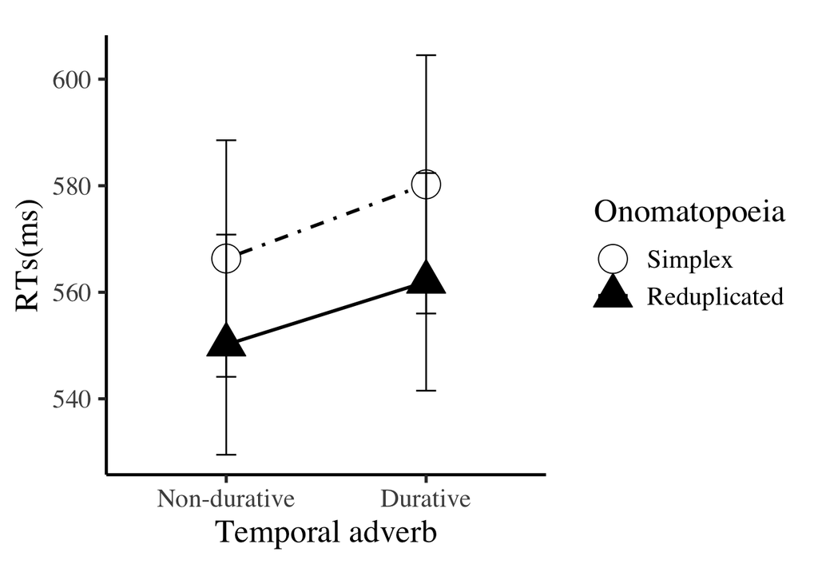

```r
g <- g + theme_classic(base_size=20, base_family="HiraKakuProN-W3")
g <- g + theme_classic(base_size=20, base_family="Times")
g <- g + theme(aspect.ratio = 1) #Ratio of y-bar to x-bar=1
g <- g + labs(x="Temporal adverb", y=RTlabel)
print(g)
```

##### Interaction

Base

```r
rtg <- subset(rt_data_summary,region==criticalregion+1)
g <- ggplot(rtg,aes(x=A,y=mean,group=Conditions))
```

Add lines

```r
g <- g + geom_line(size=1,aes(group=B,linetype=B))
g <- g + scale_linetype_manual(values=c("dotdash","solid"))
g <- g + labs(linetype=Blabel)
```

Add points

```r
g <- g + geom_point(size=8,aes(shape=B,fill=B))
g <- g + scale_shape_manual(values=c(21,24,24,25))
g <- g + scale_fill_manual(values=c("white","black","white","black"))
g <- g + labs(shape=Blabel)
g <- g + labs(fill=Blabel)
```

Add error bars

```r
g <- g + geom_errorbar(aes(ymin=mean-ci, ymax=mean+ci), width=.1)
```

Adjust x-axis breaks

```r
#g <- g + scale_x_continuous(breaks=seq(1, 10, by=1))
```

Adjust appearance

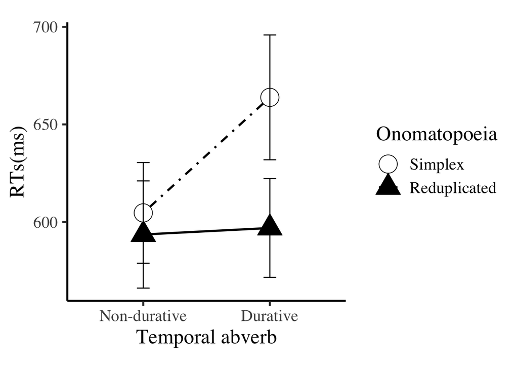

```r
g <- g + theme_classic(base_size=20, base_family="HiraKakuProN-W3")
g <- g + theme_classic(base_size=20, base_family="Times")
g <- g + theme(aspect.ratio = 1) #Ratio of y-bar to x-bar=1
g <- g + labs(x="Temporal abverb", y=RTlabel)
print(g)
```

##### Interaction

Base

```r
rtg <- subset(rt_data_summary,region==criticalregion+2)
g <- ggplot(rtg,aes(x=A,y=mean,group=Conditions))
```

Add lines

```r
g <- g + geom_line(size=1,aes(group=B,linetype=B))
g <- g + scale_linetype_manual(values=c("dotdash","solid"))
g <- g + labs(linetype=Blabel)
```

Add points

```r
g <- g + geom_point(size=8,aes(shape=B,fill=B))
g <- g + scale_shape_manual(values=c(21,24,24,25))
g <- g + scale_fill_manual(values=c("white","black","black","white"))
g <- g + labs(shape=Blabel)
g <- g + labs(fill=Blabel)
```

Add error bars

```r
g <- g + geom_errorbar(aes(ymin=mean-ci, ymax=mean+ci), width=.1)
```

Adjust x-axis breaks

```r
#g <- g + scale_x_continuous(breaks=seq(1, 10, by=1))
```

Adjust appearance

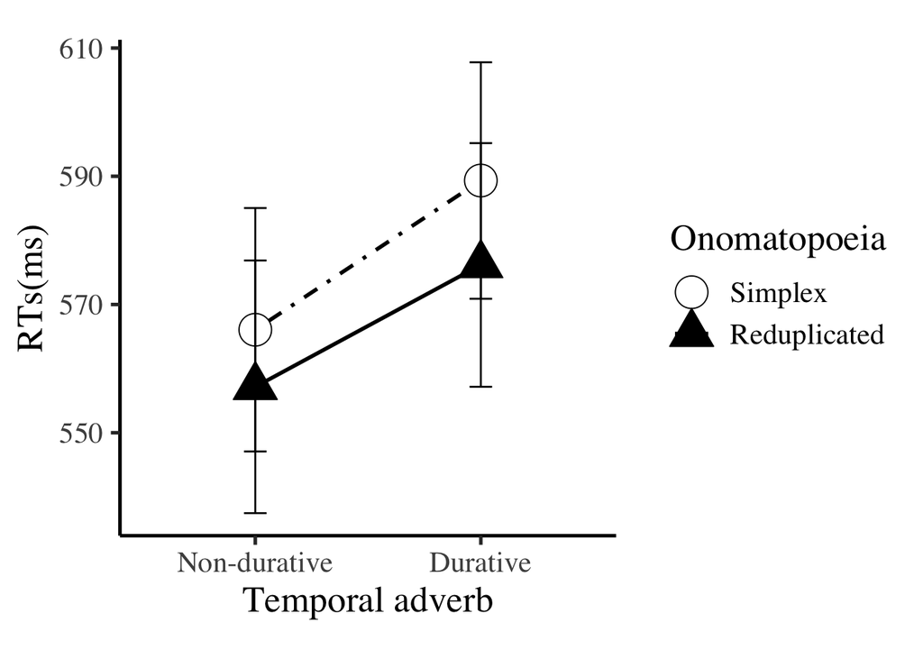

```r
g <- g + theme_classic(base_size=20, base_family="HiraKakuProN-W3")
g <- g + theme_classic(base_size=20, base_family="Times")
g <- g + theme(aspect.ratio = 1) #Ratio of y-bar to x-bar=1
g <- g + labs(x="Temporal adverb", y=RTlabel)
print(g)
```

## Coding factors

##### CONDITIONS:

```r
rt_data$Adv<-ifelse(rt_data$cond%in%c("Dr","Ds"),1,-1)
rt_data$Onom<-ifelse(rt_data$cond%in%c("Ds","Cs"),1,-1)

# For pairwise comparisons
rt_data$simplexVSredup_dur <-ifelse(rt_data$Adv==1,
                          ifelse(rt_data$Onom==1,1,-1),
                          0)
rt_data$simplexVSredup_nondur <-ifelse(rt_data$Adv==-1,
                          ifelse(rt_data$Onom==1,1,-1),
                          0)
rt_data$durVSnondur_simplex <-ifelse(rt_data$Onom==1,
                          ifelse(rt_data$Adv==1,1,-1),
                          0)
rt_data$durVSnondur_redup <-ifelse(rt_data$Onom==-1,
                          ifelse(rt_data$Adv==1,1,-1),
                          0)
```

rt_data check

```r
dc <- subset(rt_data,cond=="Cr",c(cond,word,Adv,Onom))
head(dc, n=7)
```

```
##   cond         word Adv Onom
## 1   Cr       生徒が  -1   -1
## 2   Cr       その時  -1   -1
## 3   Cr       黒板を  -1   -1
## 4   Cr     ちらちら  -1   -1
## 5   Cr     見たので  -1   -1
## 6   Cr       先生が  -1   -1
## 7   Cr カンニングを  -1   -1
```

```r
dc <- subset(rt_data,cond=="Cs",c(cond,word,Adv,Onom))
head(dc, n=7)
```

```
##    cond         word Adv Onom
## 9    Cs       生徒が  -1    1
## 10   Cs       その時  -1    1
## 11   Cs       黒板を  -1    1
## 12   Cs     ちらっと  -1    1
## 13   Cs     見たので  -1    1
## 14   Cs       先生が  -1    1
## 15   Cs カンニングを  -1    1
```

```r
dc <- subset(rt_data,cond=="Dr",c(cond,word,Adv,Onom))
head(dc, n=7)
```

```
##    cond         word Adv Onom
## 33   Dr       生徒が   1   -1
## 34   Dr     しばらく   1   -1
## 35   Dr       黒板を   1   -1
## 36   Dr     ちらちら   1   -1
## 37   Dr     見たので   1   -1
## 38   Dr       先生が   1   -1
## 39   Dr カンニングを   1   -1
```

```r
dc <- subset(rt_data,cond=="Ds",c(cond,word,Adv,Onom))
head(dc, n=7)
```

```
##    cond         word Adv Onom
## 73   Ds       生徒が   1    1
## 74   Ds     しばらく   1    1
## 75   Ds       黒板を   1    1
## 76   Ds     ちらっと   1    1
## 77   Ds     見たので   1    1
## 78   Ds       先生が   1    1
## 79   Ds カンニングを   1    1
```

##### Make sure factors are treated as factors

```r
rt_data$subj<-factor(rt_data$subj)
rt_data$expt<-factor(rt_data$expt)
rt_data$item<-factor(rt_data$item)
rt_data$cond<-factor(rt_data$cond)
rt_data$word<-factor(rt_data$word)
```

#### Critical(Onomatopoeia) region

```r
cregion<-subset(rt_data,region==criticalregion)
```

##### Check words

```r
sort(unique(cregion$word))
```

```
##  [1] カチャカチャ カチャッと   キュキュッと キュッと     ぐさぐさ
##  [6] ぐさっと     ぐらぐら     ぐらっと     クルクル     ぐるぐる
## [11] クルッと     ぐるっと     ごほごほ     ごほっと     サクサク
## [16] ざくざく     サクッと     ざくっと     ずきずき     ずきっと
## [21] ズルズル     ズルッと     ちらちら     ちらっと     ぱしゃっと
## [26] ぱしゃぱしゃ ぱちっと     ぱちぱち     ぱらっと     ぱらぱら
## [31] バンッと     バンバン     ぴかっと     ぴかぴか     ピョンと
## [36] ピョンピョン ぶんっと     ぶんぶん     ぺこっと     ぺこぺこ
## [41] ボキッと     ポキッと     ボキボキ     ポキポキ     ポロッと
## [46] ポロポロ
## 189 Levels: あがった。 あげた。 アルバイトが お辞儀したので ... 鼻を
```

##### Max model

```r
mm<-lmer(rt~Adv+Onom+Adv:Onom+
           (1+Adv+Onom+Adv:Onom|subj)+(1+Adv+Onom+Adv:Onom|item),
           control=lmerControl(optimizer="bobyqa"),
           cregion)
```

```
## boundary (singular) fit: see help('isSingular')
```

```r
summary(mm)
```

```
## Linear mixed model fit by REML. t-tests use Satterthwaite's method [
## lmerModLmerTest]
## Formula: rt ~ Adv + Onom + Adv:Onom + (1 + Adv + Onom + Adv:Onom | subj) +
##     (1 + Adv + Onom + Adv:Onom | item)
##    Data: cregion
## Control: lmerControl(optimizer = "bobyqa")
##
## REML criterion at convergence: 29502.9
##
## Scaled residuals:
##     Min      1Q  Median      3Q     Max
## -2.6937 -0.5049 -0.1718  0.2847  6.1278
##
## Random effects:
##  Groups   Name        Variance Std.Dev. Corr
##  subj     (Intercept) 32752.47 180.976
##           Adv           431.45  20.771  0.19
##           Onom          309.27  17.586  0.64 0.74
##           Adv:Onom      410.61  20.263  0.12 0.96 0.79
##  item     (Intercept)   968.57  31.122
##           Adv           167.94  12.959  0.64
##           Onom           14.59   3.819  1.00 0.70
##           Adv:Onom      164.22  12.815  0.41 0.96 0.48
##  Residual             34418.55 185.522
## Number of obs: 2191, groups:  subj, 110; item, 24
##
## Fixed effects:
##             Estimate Std. Error       df t value Pr(>|t|)
## (Intercept) 566.1888    18.8330 120.0963  30.064   <2e-16 ***
## Adv           5.6269     5.2240  37.7959   1.077    0.288
## Onom          6.2894     4.4367 115.6290   1.418    0.159
## Adv:Onom     -0.8627     5.1824  34.6346  -0.166    0.869
## ---
## Signif. codes:  0 '***' 0.001 '**' 0.01 '*' 0.05 '.' 0.1 ' ' 1
##
## Correlation of Fixed Effects:
##          (Intr) Adv   Onom
## Adv      0.165
## Onom     0.277  0.183
## Adv:Onom 0.113  0.366 0.112
## optimizer (bobyqa) convergence code: 0 (OK)
## boundary (singular) fit: see help('isSingular')
```

```r
(step_res <- step(mm, reduce.fixed = F))
```

[output not shown]

```
## boundary (singular) fit: see help('isSingular')
## boundary (singular) fit: see help('isSingular')
## boundary (singular) fit: see help('isSingular')
## boundary (singular) fit: see help('isSingular')
```

```
## Backward reduced random-effect table:
##
##                                                Eliminated npar logLik   AIC
## <none>                                                      25 -14752 29553
## Adv:Onom in (1 + Adv + Onom + Adv:Onom | item)          1   21 -14754 29549
## Onom in (Adv + Onom | item)                             2   18 -14754 29544
## Adv in (Adv | item)                                     3   16 -14756 29543
## Adv:Onom in (1 + Adv + Onom + Adv:Onom | subj)          0   12 -14761 29546
## (1 | item)                                              0   15 -14770 29570
##                                                    LRT Df Pr(>Chisq)
## <none>
## Adv:Onom in (1 + Adv + Onom + Adv:Onom | item)  4.4614  4    0.34715
## Onom in (Adv + Onom | item)                     0.9098  3    0.82307
## Adv in (Adv | item)                             3.1158  2    0.21057
## Adv:Onom in (1 + Adv + Onom + Adv:Onom | subj) 11.0606  4    0.02589 *
## (1 | item)                                     28.1775  1  1.107e-07 ***
## ---
## Signif. codes:  0 '***' 0.001 '**' 0.01 '*' 0.05 '.' 0.1 ' ' 1
##
## Backward reduced fixed-effect table:
## Degrees of freedom method: Satterthwaite
##
##          Eliminated Sum Sq Mean Sq NumDF  DenDF F value Pr(>F)
## Adv:Onom          0 931.55  931.55     1 181.63  0.0268 0.8701
##
## Model found:
## rt ~ Adv + Onom + (1 + Adv + Onom + Adv:Onom | subj) + (1 | item) + Adv:Onom
```

```r
final <- get_model(step_res)
summary(final)
```

```
## Linear mixed model fit by REML. t-tests use Satterthwaite's method [
## lmerModLmerTest]
## Formula: rt ~ Adv + Onom + (1 + Adv + Onom + Adv:Onom | subj) + (1 | item) +
##     Adv:Onom
##    Data: cregion
## Control: lmerControl(optimizer = "bobyqa")
##
## REML criterion at convergence: 29511.4
##
## Scaled residuals:
##     Min      1Q  Median      3Q     Max
## -2.7105 -0.5010 -0.1745  0.2735  6.3324
##
## Random effects:
##  Groups   Name        Variance Std.Dev. Corr
##  subj     (Intercept) 32768.7  181.02
##           Adv           449.9   21.21   0.20
##           Onom          310.2   17.61   0.66 0.75
##           Adv:Onom      414.3   20.35   0.13 0.97 0.79
##  item     (Intercept)  1016.5   31.88
##  Residual             34749.4  186.41
## Number of obs: 2191, groups:  subj, 110; item, 24
##
## Fixed effects:
##             Estimate Std. Error       df t value Pr(>|t|)
## (Intercept) 566.4360    18.8973 119.9461  29.974   <2e-16 ***
## Adv           5.6225     4.5349 135.0064   1.240    0.217
## Onom          6.2636     4.3791 160.3476   1.430    0.155
## Adv:Onom     -0.7326     4.4743 181.6334  -0.164    0.870
## ---
## Signif. codes:  0 '***' 0.001 '**' 0.01 '*' 0.05 '.' 0.1 ' ' 1
##
## Correlation of Fixed Effects:
##          (Intr) Adv   Onom
## Adv      0.066
## Onom     0.225  0.148
## Adv:Onom 0.055  0.156 0.082
## optimizer (bobyqa) convergence code: 0 (OK)
## boundary (singular) fit: see help('isSingular')
```

```r
anova(final)
```

```
## Type III Analysis of Variance Table with Satterthwaite's method
##          Sum Sq Mean Sq NumDF  DenDF F value Pr(>F)
## Adv       53416   53416     1 135.01  1.5372 0.2172
## Onom      71093   71093     1 160.35  2.0459 0.1546
## Adv:Onom    932     932     1 181.63  0.0268 0.8701
```

#### Verb region

```r
cregion<-subset(rt_data,region==criticalregion+1)
```

##### Check words

```r
sort(unique(cregion$word))
```

```
##  [1] お辞儀したので   すすったので     まばたきしたので めくったので
##  [5] 光ったので       切ったので       刺したので       刻んだので
##  [9] 叩いたので       咳き込んだので   回したので       回ったので
## [13] 折ったので       拭いたので       振ったので       揺れたので
## [17] 撮ったので       流したので       混ぜたので       痛んだので
## [21] 発砲したので     見たので         飛び越えたので   鳴らしたので
## 189 Levels: あがった。 あげた。 アルバイトが お辞儀したので ... 鼻を
```

##### Max model

```r
mm<-lmer(rt~Adv+Onom+Adv:Onom+
           (1+Adv+Onom+Adv:Onom|subj)+(1+Adv+Onom+Adv:Onom|item),
           control=lmerControl(optimizer="bobyqa"),
           cregion)
```

```
## boundary (singular) fit: see help('isSingular')
```

```r
summary(mm)
```

```
## Linear mixed model fit by REML. t-tests use Satterthwaite's method [
## lmerModLmerTest]
## Formula: rt ~ Adv + Onom + Adv:Onom + (1 + Adv + Onom + Adv:Onom | subj) +
##     (1 + Adv + Onom + Adv:Onom | item)
##    Data: cregion
## Control: lmerControl(optimizer = "bobyqa")
##
## REML criterion at convergence: 30292
##
## Scaled residuals:
##     Min      1Q  Median      3Q     Max
## -2.9946 -0.5019 -0.1672  0.2298  5.9070
##
## Random effects:
##  Groups   Name        Variance Std.Dev. Corr
##  subj     (Intercept) 52357.9  228.82
##           Adv           729.9   27.02   0.63
##           Onom          726.3   26.95   0.49  0.99
##           Adv:Onom      890.9   29.85   0.79  0.97  0.92
##  item     (Intercept)  3702.7   60.85
##           Adv           346.9   18.63    0.27
##           Onom          103.9   10.19    0.84 -0.05
##           Adv:Onom      289.9   17.03    0.67  0.83  0.51
##  Residual             53563.6  231.44
## Number of obs: 2177, groups:  subj, 110; item, 24
##
## Fixed effects:
##             Estimate Std. Error      df t value Pr(>|t|)
## (Intercept)  619.665     25.632 114.647  24.176  < 2e-16 ***
## Adv           12.444      6.875  29.436   1.810  0.08052 .
## Onom          17.655      6.042  48.691   2.922  0.00526 **
## Adv:Onom      14.056      6.759  35.593   2.080  0.04482 *
## ---
## Signif. codes:  0 '***' 0.001 '**' 0.01 '*' 0.05 '.' 0.1 ' ' 1
##
## Correlation of Fixed Effects:
##          (Intr) Adv   Onom
## Adv      0.260
## Onom     0.312  0.163
## Adv:Onom 0.455  0.376 0.222
## optimizer (bobyqa) convergence code: 0 (OK)
## boundary (singular) fit: see help('isSingular')
```

```r
(step_res <- step(mm, reduce.fixed = F))
```

[output not shown]

```
## Backward reduced random-effect table:
##
##                                                Eliminated npar logLik   AIC
## <none>                                                      25 -15146 30342
## Adv:Onom in (1 + Adv + Onom + Adv:Onom | item)          1   21 -15149 30340
## Adv in (Adv + Onom | item)                              2   18 -15151 30338
## Onom in (Onom | item)                                   3   16 -15152 30336
## Adv:Onom in (1 + Adv + Onom + Adv:Onom | subj)          0   12 -15164 30352
## (1 | item)                                              0   15 -15196 30421
##                                                   LRT Df Pr(>Chisq)
## <none>
## Adv:Onom in (1 + Adv + Onom + Adv:Onom | item)  6.206  4     0.1843
## Adv in (Adv + Onom | item)                      3.363  3     0.3390
## Onom in (Onom | item)                           2.616  2     0.2704
## Adv:Onom in (1 + Adv + Onom + Adv:Onom | subj) 23.657  4  9.355e-05 ***
## (1 | item)                                     86.908  1  < 2.2e-16 ***
## ---
## Signif. codes:  0 '***' 0.001 '**' 0.01 '*' 0.05 '.' 0.1 ' ' 1
##
## Backward reduced fixed-effect table:
## Degrees of freedom method: Satterthwaite
##
##          Eliminated Sum Sq Mean Sq NumDF  DenDF F value  Pr(>F)
## Adv:Onom          0 358175  358175     1 155.28  6.5937 0.01118 *
## ---
## Signif. codes:  0 '***' 0.001 '**' 0.01 '*' 0.05 '.' 0.1 ' ' 1
##
## Model found:
## rt ~ Adv + Onom + (1 + Adv + Onom + Adv:Onom | subj) + (1 | item) + Adv:Onom
```

```r
final <- get_model(step_res)
summary(final)
```

```
## Linear mixed model fit by REML. t-tests use Satterthwaite's method [
## lmerModLmerTest]
## Formula: rt ~ Adv + Onom + (1 + Adv + Onom + Adv:Onom | subj) + (1 | item) +
##     Adv:Onom
##    Data: cregion
## Control: lmerControl(optimizer = "bobyqa")
##
## REML criterion at convergence: 30304.2
##
## Scaled residuals:
##    Min     1Q Median     3Q    Max
## -2.955 -0.500 -0.162  0.231  6.147
##
## Random effects:
##  Groups   Name        Variance Std.Dev. Corr
##  subj     (Intercept) 52305.4  228.70
##           Adv           712.1   26.69   0.63
##           Onom          703.4   26.52   0.50 0.99
##           Adv:Onom      911.7   30.20   0.79 0.98 0.93
##  item     (Intercept)  3663.5   60.53
##  Residual             54320.7  233.07
## Number of obs: 2177, groups:  subj, 110; item, 24
##
## Fixed effects:
##             Estimate Std. Error      df t value Pr(>|t|)
## (Intercept)  619.871     25.595 115.131  24.219  < 2e-16 ***
## Adv           12.856      5.706 153.503   2.253  0.02566 *
## Onom          17.492      5.672 150.601   3.084  0.00243 **
## Adv:Onom      14.943      5.819 155.283   2.568  0.01118 *
## ---
## Signif. codes:  0 '***' 0.001 '**' 0.01 '*' 0.05 '.' 0.1 ' ' 1
##
## Correlation of Fixed Effects:
##          (Intr) Adv   Onom
## Adv      0.227
## Onom     0.184  0.219
## Adv:Onom 0.336  0.185 0.164
## optimizer (bobyqa) convergence code: 0 (OK)
## boundary (singular) fit: see help('isSingular')
```

```r
anova(final)
```

```
## Type III Analysis of Variance Table with Satterthwaite's method
##          Sum Sq Mean Sq NumDF  DenDF F value   Pr(>F)
## Adv      275775  275775     1 153.50  5.0768 0.025665 *
## Onom     516543  516543     1 150.60  9.5092 0.002433 **
## Adv:Onom 358175  358175     1 155.28  6.5937 0.011178 *
## ---
## Signif. codes:  0 '***' 0.001 '**' 0.01 '*' 0.05 '.' 0.1 ' ' 1
```

```r
mm<-lmer(rt~Adv+Onom+Adv:Onom+Adv:Itemvalue+Onom:Itemvalue+Adv:Onom:Itemvalue+Itemvalue+
           (1+Adv+Onom+Adv:Onom|subj),
           control=lmerControl(optimizer="bobyqa"),
           cregion)
```

```
## boundary (singular) fit: see help('isSingular')
```

```r
summary(mm)
```

```
## Linear mixed model fit by REML. t-tests use Satterthwaite's method [
## lmerModLmerTest]
## Formula: rt ~ Adv + Onom + Adv:Onom + Adv:Itemvalue + Onom:Itemvalue +
##     Adv:Onom:Itemvalue + Itemvalue + (1 + Adv + Onom + Adv:Onom |      subj)
##    Data: cregion
## Control: lmerControl(optimizer = "bobyqa")
##
## REML criterion at convergence: 30365.8
##
## Scaled residuals:
##     Min      1Q  Median      3Q     Max
## -2.8065 -0.5075 -0.1862  0.2342  6.4667
##
## Random effects:
##  Groups   Name        Variance Std.Dev. Corr
##  subj     (Intercept) 52073.7  228.20
##           Adv           869.9   29.49   0.62
##           Onom          609.1   24.68   0.54 0.97
##           Adv:Onom     1295.2   35.99   0.68 0.89 0.96
##  Residual             57645.4  240.09
## Number of obs: 2177, groups:  subj, 110
##
## Fixed effects:
##                    Estimate Std. Error       df t value Pr(>|t|)
## (Intercept)         618.605     22.371  107.926  27.652  < 2e-16 ***
## Adv                  14.693      5.907  104.254   2.487  0.01445 *
## Onom                 18.362      5.705  183.702   3.219  0.00152 **
## Itemvalue             2.355      5.475 1318.178   0.430  0.66719
## Adv:Onom             12.928      6.228  106.961   2.076  0.04031 *
## Adv:Itemvalue        -4.931      5.958 1763.268  -0.828  0.40794
## Onom:Itemvalue      -10.360      5.685 1201.785  -1.822  0.06866 .
## Adv:Onom:Itemvalue    3.342      5.844 1623.183   0.572  0.56751
## ---
## Signif. codes:  0 '***' 0.001 '**' 0.01 '*' 0.05 '.' 0.1 ' ' 1
##
## Correlation of Fixed Effects:
##             (Intr) Adv    Onom   Itemvl Adv:On Adv:It Onm:It
## Adv          0.277
## Onom         0.210  0.208
## Itemvalue   -0.010  0.022 -0.025
## Adv:Onom     0.369  0.213  0.177  0.008
## Adv:Itemval  0.006 -0.046  0.012 -0.013 -0.018
## Onom:Itemvl -0.008  0.010 -0.018  0.026  0.007  0.064
## Adv:Onm:Itm  0.001 -0.015  0.029  0.096 -0.042  0.002 -0.002
## optimizer (bobyqa) convergence code: 0 (OK)
## boundary (singular) fit: see help('isSingular')
```

```r
(step_res <- step(mm, reduce.fixed = F))
```

```
## boundary (singular) fit: see help('isSingular')
```

```
## Backward reduced random-effect table:
##
##                                                Eliminated npar logLik   AIC
## <none>                                                      19 -15183 30404
## Adv:Onom in (1 + Adv + Onom + Adv:Onom | subj)          0   15 -15195 30420
##                                                   LRT Df Pr(>Chisq)
## <none>
## Adv:Onom in (1 + Adv + Onom + Adv:Onom | subj) 24.588  4  6.087e-05 ***
## ---
## Signif. codes:  0 '***' 0.001 '**' 0.01 '*' 0.05 '.' 0.1 ' ' 1
##
## Backward reduced fixed-effect table:
## Degrees of freedom method: Satterthwaite
##
##                    Eliminated Sum Sq Mean Sq NumDF  DenDF F value Pr(>F)
## Adv:Onom:Itemvalue          0  18850   18850     1 1623.2   0.327 0.5675
##
## Model found:
## rt ~ Adv + Onom + Adv:Onom + Adv:Itemvalue + Onom:Itemvalue + Adv:Onom:Itemvalue + Itemvalue + (1 + Adv + Onom + Adv:Onom | subj)
```

```r
final <- get_model(step_res)
summary(final)
```

```
## Linear mixed model fit by REML. t-tests use Satterthwaite's method [
## lmerModLmerTest]
## Formula: rt ~ Adv + Onom + Adv:Onom + Adv:Itemvalue + Onom:Itemvalue +
##     Adv:Onom:Itemvalue + Itemvalue + (1 + Adv + Onom + Adv:Onom |      subj)
##    Data: cregion
## Control: lmerControl(optimizer = "bobyqa")
##
## REML criterion at convergence: 30365.8
##
## Scaled residuals:
##     Min      1Q  Median      3Q     Max
## -2.8065 -0.5075 -0.1862  0.2342  6.4667
##
## Random effects:
##  Groups   Name        Variance Std.Dev. Corr
##  subj     (Intercept) 52073.7  228.20
##           Adv           869.9   29.49   0.62
##           Onom          609.1   24.68   0.54 0.97
##           Adv:Onom     1295.2   35.99   0.68 0.89 0.96
##  Residual             57645.4  240.09
## Number of obs: 2177, groups:  subj, 110
##
## Fixed effects:
##                    Estimate Std. Error       df t value Pr(>|t|)
## (Intercept)         618.605     22.371  107.926  27.652  < 2e-16 ***
## Adv                  14.693      5.907  104.254   2.487  0.01445 *
## Onom                 18.362      5.705  183.702   3.219  0.00152 **
## Itemvalue             2.355      5.475 1318.178   0.430  0.66719
## Adv:Onom             12.928      6.228  106.961   2.076  0.04031 *
## Adv:Itemvalue        -4.931      5.958 1763.268  -0.828  0.40794
## Onom:Itemvalue      -10.360      5.685 1201.785  -1.822  0.06866 .
## Adv:Onom:Itemvalue    3.342      5.844 1623.183   0.572  0.56751
## ---
## Signif. codes:  0 '***' 0.001 '**' 0.01 '*' 0.05 '.' 0.1 ' ' 1
##
## Correlation of Fixed Effects:
##             (Intr) Adv    Onom   Itemvl Adv:On Adv:It Onm:It
## Adv          0.277
## Onom         0.210  0.208
## Itemvalue   -0.010  0.022 -0.025
## Adv:Onom     0.369  0.213  0.177  0.008
## Adv:Itemval  0.006 -0.046  0.012 -0.013 -0.018
## Onom:Itemvl -0.008  0.010 -0.018  0.026  0.007  0.064
## Adv:Onm:Itm  0.001 -0.015  0.029  0.096 -0.042  0.002 -0.002
## optimizer (bobyqa) convergence code: 0 (OK)
## boundary (singular) fit: see help('isSingular')
```

```r
anova(final)
```

```
## Type III Analysis of Variance Table with Satterthwaite's method
##                    Sum Sq Mean Sq NumDF   DenDF F value   Pr(>F)
## Adv                356681  356681     1  104.25  6.1875 0.014451 *
## Onom               597182  597182     1  183.70 10.3596 0.001523 **
## Itemvalue           10664   10664     1 1318.18  0.1850 0.667186
## Adv:Onom           248401  248401     1  106.96  4.3091 0.040306 *
## Adv:Itemvalue       39494   39494     1 1763.27  0.6851 0.407942
## Onom:Itemvalue     191427  191427     1 1201.78  3.3208 0.068658 .
## Adv:Onom:Itemvalue  18850   18850     1 1623.18  0.3270 0.567514
## ---
## Signif. codes:  0 '***' 0.001 '**' 0.01 '*' 0.05 '.' 0.1 ' ' 1
```

#### Onom x itemvalue in non-durative

```r
mm<-lmer(rt~simplexVSredup_dur:Itemvalue+simplexVSredup_nondur:Itemvalue+Adv+Onom+Itemvalue+Adv:Itemvalue+Adv:Onom+
           (1+Adv+Onom+Adv:Onom|subj),
           control=lmerControl(optimizer="bobyqa"),
           cregion)
```

```
## boundary (singular) fit: see help('isSingular')
```

```r
summary(mm)
```

```
## Linear mixed model fit by REML. t-tests use Satterthwaite's method [
## lmerModLmerTest]
## Formula: rt ~ simplexVSredup_dur:Itemvalue + simplexVSredup_nondur:Itemvalue +
##     Adv + Onom + Itemvalue + Adv:Itemvalue + Adv:Onom + (1 +
##     Adv + Onom + Adv:Onom | subj)
##    Data: cregion
## Control: lmerControl(optimizer = "bobyqa")
##
## REML criterion at convergence: 30364.4
##
## Scaled residuals:
##     Min      1Q  Median      3Q     Max
## -2.8065 -0.5075 -0.1862  0.2342  6.4667
##
## Random effects:
##  Groups   Name        Variance Std.Dev. Corr
##  subj     (Intercept) 52073.7  228.20
##           Adv           869.9   29.49   0.62
##           Onom          609.1   24.68   0.54 0.97
##           Adv:Onom     1295.2   35.99   0.68 0.89 0.96
##  Residual             57645.4  240.09
## Number of obs: 2177, groups:  subj, 110
##
## Fixed effects:
##                                 Estimate Std. Error       df t value Pr(>|t|)
## (Intercept)                      618.605     22.371  107.926  27.652  < 2e-16
## Adv                               14.693      5.907  104.253   2.487  0.01445
## Onom                              18.362      5.705  183.702   3.219  0.00152
## Itemvalue                          2.355      5.475 1318.170   0.430  0.66718
## simplexVSredup_dur:Itemvalue      -7.018      8.143 1538.509  -0.862  0.38891
## Itemvalue:simplexVSredup_nondur  -13.702      8.163 1329.401  -1.679  0.09348
## Itemvalue:Adv                     -4.931      5.958 1763.269  -0.828  0.40794
## Adv:Onom                          12.928      6.228  106.961   2.076  0.04031
##
## (Intercept)                     ***
## Adv                             *
## Onom                            **
## Itemvalue
## simplexVSredup_dur:Itemvalue
## Itemvalue:simplexVSredup_nondur .
## Itemvalue:Adv
## Adv:Onom                        *
## ---
## Signif. codes:  0 '***' 0.001 '**' 0.01 '*' 0.05 '.' 0.1 ' ' 1
##
## Correlation of Fixed Effects:
##             (Intr) Adv    Onom   Itemvl sVS_:I It:VS_ Itmv:A
## Adv          0.277
## Onom         0.210  0.208
## Itemvalue   -0.010  0.022 -0.025
## smplxVSr_:I -0.005 -0.004  0.008  0.087
## Itmvl:smVS_ -0.006  0.018 -0.034 -0.050 -0.028
## Itemval:Adv  0.006 -0.046  0.012 -0.013  0.046  0.043
## Adv:Onom     0.369  0.213  0.177  0.008 -0.025  0.035 -0.018
## optimizer (bobyqa) convergence code: 0 (OK)
## boundary (singular) fit: see help('isSingular')
```

```r
(step_res <- step(mm, reduce.fixed = F))
```

```
## boundary (singular) fit: see help('isSingular')
```

```
## Backward reduced random-effect table:
##
##                                                Eliminated npar logLik   AIC
## <none>                                                      19 -15182 30402
## Adv:Onom in (1 + Adv + Onom + Adv:Onom | subj)          0   15 -15194 30419
##                                                   LRT Df Pr(>Chisq)
## <none>
## Adv:Onom in (1 + Adv + Onom + Adv:Onom | subj) 24.588  4  6.087e-05 ***
## ---
## Signif. codes:  0 '***' 0.001 '**' 0.01 '*' 0.05 '.' 0.1 ' ' 1
##
## Backward reduced fixed-effect table:
## Degrees of freedom method: Satterthwaite
##
##                                 Eliminated Sum Sq Mean Sq NumDF   DenDF F value
## simplexVSredup_dur:Itemvalue             0  42818   42818     1 1538.51  0.7428
## Itemvalue:simplexVSredup_nondur          0 162415  162415     1 1329.40  2.8175
## Itemvalue:Adv                            0  39494   39494     1 1763.27  0.6851
## Adv:Onom                                 0 248401  248401     1  106.96  4.3091
##                                  Pr(>F)
## simplexVSredup_dur:Itemvalue    0.38891
## Itemvalue:simplexVSredup_nondur 0.09348 .
## Itemvalue:Adv                   0.40794
## Adv:Onom                        0.04031 *
## ---
## Signif. codes:  0 '***' 0.001 '**' 0.01 '*' 0.05 '.' 0.1 ' ' 1
##
## Model found:
## rt ~ simplexVSredup_dur:Itemvalue + simplexVSredup_nondur:Itemvalue + Adv + Onom + Itemvalue + Adv:Itemvalue + Adv:Onom + (1 + Adv + Onom + Adv:Onom | subj)
```

```r
final <- get_model(step_res)
summary(final)
```

```
## Linear mixed model fit by REML. t-tests use Satterthwaite's method [
## lmerModLmerTest]
## Formula: rt ~ simplexVSredup_dur:Itemvalue + simplexVSredup_nondur:Itemvalue +
##     Adv + Onom + Itemvalue + Adv:Itemvalue + Adv:Onom + (1 +
##     Adv + Onom + Adv:Onom | subj)
##    Data: cregion
## Control: lmerControl(optimizer = "bobyqa")
##
## REML criterion at convergence: 30364.4
##
## Scaled residuals:
##     Min      1Q  Median      3Q     Max
## -2.8065 -0.5075 -0.1862  0.2342  6.4667
##
## Random effects:
##  Groups   Name        Variance Std.Dev. Corr
##  subj     (Intercept) 52073.7  228.20
##           Adv           869.9   29.49   0.62
##           Onom          609.1   24.68   0.54 0.97
##           Adv:Onom     1295.2   35.99   0.68 0.89 0.96
##  Residual             57645.4  240.09
## Number of obs: 2177, groups:  subj, 110
##
## Fixed effects:
##                                 Estimate Std. Error       df t value Pr(>|t|)
## (Intercept)                      618.605     22.371  107.926  27.652  < 2e-16
## Adv                               14.693      5.907  104.253   2.487  0.01445
## Onom                              18.362      5.705  183.702   3.219  0.00152
## Itemvalue                          2.355      5.475 1318.170   0.430  0.66718
## simplexVSredup_dur:Itemvalue      -7.018      8.143 1538.509  -0.862  0.38891
## Itemvalue:simplexVSredup_nondur  -13.702      8.163 1329.401  -1.679  0.09348
## Itemvalue:Adv                     -4.931      5.958 1763.269  -0.828  0.40794
## Adv:Onom                          12.928      6.228  106.961   2.076  0.04031
##
## (Intercept)                     ***
## Adv                             *
## Onom                            **
## Itemvalue
## simplexVSredup_dur:Itemvalue
## Itemvalue:simplexVSredup_nondur .
## Itemvalue:Adv
## Adv:Onom                        *
## ---
## Signif. codes:  0 '***' 0.001 '**' 0.01 '*' 0.05 '.' 0.1 ' ' 1
##
## Correlation of Fixed Effects:
##             (Intr) Adv    Onom   Itemvl sVS_:I It:VS_ Itmv:A
## Adv          0.277
## Onom         0.210  0.208
## Itemvalue   -0.010  0.022 -0.025
## smplxVSr_:I -0.005 -0.004  0.008  0.087
## Itmvl:smVS_ -0.006  0.018 -0.034 -0.050 -0.028
## Itemval:Adv  0.006 -0.046  0.012 -0.013  0.046  0.043
## Adv:Onom     0.369  0.213  0.177  0.008 -0.025  0.035 -0.018
## optimizer (bobyqa) convergence code: 0 (OK)
## boundary (singular) fit: see help('isSingular')
```

```r
anova(final)
```

```
## Type III Analysis of Variance Table with Satterthwaite's method
##                                 Sum Sq Mean Sq NumDF   DenDF F value   Pr(>F)
## Adv                             356682  356682     1  104.25  6.1875 0.014451
## Onom                            597182  597182     1  183.70 10.3596 0.001523
## Itemvalue                        10664   10664     1 1318.17  0.1850 0.667184
## simplexVSredup_dur:Itemvalue     42818   42818     1 1538.51  0.7428 0.388908
## Itemvalue:simplexVSredup_nondur 162415  162415     1 1329.40  2.8175 0.093477
## Itemvalue:Adv                    39494   39494     1 1763.27  0.6851 0.407942
## Adv:Onom                        248401  248401     1  106.96  4.3091 0.040306
##
## Adv                             *
## Onom                            **
## Itemvalue
## simplexVSredup_dur:Itemvalue
## Itemvalue:simplexVSredup_nondur .
## Itemvalue:Adv
## Adv:Onom                        *
## ---
## Signif. codes:  0 '***' 0.001 '**' 0.01 '*' 0.05 '.' 0.1 ' ' 1
```

##### Post hoc multiple pairwise comparisons to test the interaction

```r
mmm<-lmer(rt~simplexVSredup_dur+simplexVSredup_nondur+Adv+
           (1+Adv+Onom+Adv:Onom|subj)+(1+Adv+Onom+Adv:Onom|item),
           control=lmerControl(optimizer="bobyqa"),
           cregion)
```

```
## boundary (singular) fit: see help('isSingular')
```

```r
summary(mmm)
```

```
## Linear mixed model fit by REML. t-tests use Satterthwaite's method [
## lmerModLmerTest]
## Formula: rt ~ simplexVSredup_dur + simplexVSredup_nondur + Adv + (1 +
##     Adv + Onom + Adv:Onom | subj) + (1 + Adv + Onom + Adv:Onom |      item)
##    Data: cregion
## Control: lmerControl(optimizer = "bobyqa")
##
## REML criterion at convergence: 30290.6
##
## Scaled residuals:
##     Min      1Q  Median      3Q     Max
## -2.9946 -0.5019 -0.1672  0.2298  5.9070
##
## Random effects:
##  Groups   Name        Variance Std.Dev. Corr
##  subj     (Intercept) 52357.8  228.82
##           Adv           729.9   27.02   0.63
##           Onom          726.3   26.95   0.49  0.99
##           Adv:Onom      890.9   29.85   0.79  0.97  0.92
##  item     (Intercept)  3702.7   60.85
##           Adv           346.9   18.63    0.27
##           Onom          103.9   10.19    0.84 -0.05
##           Adv:Onom      289.9   17.03    0.67  0.83  0.51
##  Residual             53563.6  231.44
## Number of obs: 2177, groups:  subj, 110; item, 24
##
## Fixed effects:
##                       Estimate Std. Error      df t value Pr(>|t|)
## (Intercept)            619.665     25.632 114.647  24.176  < 2e-16 ***
## simplexVSredup_dur      31.711     10.016  36.132   3.166  0.00313 **
## simplexVSredup_nondur    3.600      8.004  49.985   0.450  0.65483
## Adv                     12.444      6.875  29.436   1.810  0.08052 .
## ---
## Signif. codes:  0 '***' 0.001 '**' 0.01 '*' 0.05 '.' 0.1 ' ' 1
##
## Correlation of Fixed Effects:
##              (Intr) smplxVSrdp_d smplxVSrdp_n
## smplxVSrdp_d  0.495
## smplxVSrdp_n -0.148 -0.114
## Adv           0.260  0.353       -0.194
## optimizer (bobyqa) convergence code: 0 (OK)
## boundary (singular) fit: see help('isSingular')
```

```r
(step_res <- step(mmm, reduce.fixed = F))
```

[output not shown]

```
## Backward reduced random-effect table:
##
##                                                Eliminated npar logLik   AIC
## <none>                                                      25 -15145 30341
## Adv:Onom in (1 + Adv + Onom + Adv:Onom | item)          1   21 -15148 30339
## Adv in (Adv + Onom | item)                              2   18 -15150 30336
## Onom in (Onom | item)                                   3   16 -15151 30335
## Adv:Onom in (1 + Adv + Onom + Adv:Onom | subj)          0   12 -15163 30350
## (1 | item)                                              0   15 -15195 30420
##                                                   LRT Df Pr(>Chisq)
## <none>
## Adv:Onom in (1 + Adv + Onom + Adv:Onom | item)  6.206  4     0.1843
## Adv in (Adv + Onom | item)                      3.363  3     0.3390
## Onom in (Onom | item)                           2.616  2     0.2704
## Adv:Onom in (1 + Adv + Onom + Adv:Onom | subj) 23.657  4  9.355e-05 ***
## (1 | item)                                     86.908  1  < 2.2e-16 ***
## ---
## Signif. codes:  0 '***' 0.001 '**' 0.01 '*' 0.05 '.' 0.1 ' ' 1
##
## Backward reduced fixed-effect table:
## Degrees of freedom method: Satterthwaite
##
##                       Eliminated Sum Sq Mean Sq NumDF  DenDF F value    Pr(>F)
## simplexVSredup_dur             0 743372  743372     1 109.61 13.6849 0.0003397
## simplexVSredup_nondur          0   6391    6391     1 996.49  0.1177 0.7316590
## Adv                            0 275775  275775     1 153.50  5.0768 0.0256650
##
## simplexVSredup_dur    ***
## simplexVSredup_nondur
## Adv                   *
## ---
## Signif. codes:  0 '***' 0.001 '**' 0.01 '*' 0.05 '.' 0.1 ' ' 1
##
## Model found:
## rt ~ simplexVSredup_dur + simplexVSredup_nondur + Adv + (1 + Adv + Onom + Adv:Onom | subj) + (1 | item)
```

```r
final <- get_model(step_res)
summary(final)
```

```
## Linear mixed model fit by REML. t-tests use Satterthwaite's method [
## lmerModLmerTest]
## Formula: rt ~ simplexVSredup_dur + simplexVSredup_nondur + Adv + (1 +
##     Adv + Onom + Adv:Onom | subj) + (1 | item)
##    Data: cregion
## Control: lmerControl(optimizer = "bobyqa")
##
## REML criterion at convergence: 30302.8
##
## Scaled residuals:
##    Min     1Q Median     3Q    Max
## -2.955 -0.500 -0.162  0.231  6.147
##
## Random effects:
##  Groups   Name        Variance Std.Dev. Corr
##  subj     (Intercept) 52305.4  228.70
##           Adv           712.1   26.69   0.63
##           Onom          703.4   26.52   0.50 0.99
##           Adv:Onom      911.7   30.20   0.79 0.98 0.93
##  item     (Intercept)  3663.5   60.53
##  Residual             54320.7  233.07
## Number of obs: 2177, groups:  subj, 110; item, 24
##
## Fixed effects:
##                       Estimate Std. Error      df t value Pr(>|t|)
## (Intercept)            619.871     25.595 115.131  24.219  < 2e-16 ***
## simplexVSredup_dur      32.434      8.768 109.614   3.699  0.00034 ***
## simplexVSredup_nondur    2.549      7.430 996.485   0.343  0.73166
## Adv                     12.856      5.706 153.503   2.253  0.02566 *
## ---
## Signif. codes:  0 '***' 0.001 '**' 0.01 '*' 0.05 '.' 0.1 ' ' 1
##
## Correlation of Fixed Effects:
##              (Intr) smplxVSrdp_d smplxVSrdp_n
## smplxVSrdp_d  0.342
## smplxVSrdp_n -0.123 -0.026
## Adv           0.227  0.265        0.022
## optimizer (bobyqa) convergence code: 0 (OK)
## boundary (singular) fit: see help('isSingular')
```

```r
anova(final)
```

```
## Type III Analysis of Variance Table with Satterthwaite's method
##                       Sum Sq Mean Sq NumDF  DenDF F value    Pr(>F)
## simplexVSredup_dur    743372  743372     1 109.61 13.6849 0.0003397 ***
## simplexVSredup_nondur   6391    6391     1 996.49  0.1177 0.7316590
## Adv                   275775  275775     1 153.50  5.0768 0.0256650 *
## ---
## Signif. codes:  0 '***' 0.001 '**' 0.01 '*' 0.05 '.' 0.1 ' ' 1
```

```r
mmm<-lmer(rt~durVSnondur_simplex+durVSnondur_redup+Onom+
           (1+Adv+Onom+Adv:Onom|subj)+(1+Adv+Onom+Adv:Onom|item),
           control=lmerControl(optimizer="bobyqa"),
           cregion)
```

```
## boundary (singular) fit: see help('isSingular')
```

```r
summary(mmm)
```

```
## Linear mixed model fit by REML. t-tests use Satterthwaite's method [
## lmerModLmerTest]
## Formula: rt ~ durVSnondur_simplex + durVSnondur_redup + Onom + (1 + Adv +
##     Onom + Adv:Onom | subj) + (1 + Adv + Onom + Adv:Onom | item)
##    Data: cregion
## Control: lmerControl(optimizer = "bobyqa")
##
## REML criterion at convergence: 30290.6
##
## Scaled residuals:
##     Min      1Q  Median      3Q     Max
## -2.9946 -0.5019 -0.1672  0.2298  5.9070
##
## Random effects:
##  Groups   Name        Variance Std.Dev. Corr
##  subj     (Intercept) 52357.8  228.82
##           Adv           729.9   27.02   0.63
##           Onom          726.3   26.95   0.49  0.99
##           Adv:Onom      890.9   29.85   0.79  0.97  0.92
##  item     (Intercept)  3702.7   60.85
##           Adv           346.9   18.63    0.27
##           Onom          103.9   10.19    0.84 -0.05
##           Adv:Onom      289.9   17.03    0.67  0.83  0.51
##  Residual             53563.6  231.44
## Number of obs: 2177, groups:  subj, 110; item, 24
##
## Fixed effects:
##                     Estimate Std. Error      df t value Pr(>|t|)
## (Intercept)          619.665     25.632 114.647  24.176  < 2e-16 ***
## durVSnondur_simplex   26.500     11.310  31.891   2.343  0.02553 *
## durVSnondur_redup     -1.611      7.615  65.498  -0.212  0.83308
## Onom                  17.655      6.042  48.692   2.922  0.00526 **
## ---
## Signif. codes:  0 '***' 0.001 '**' 0.01 '*' 0.05 '.' 0.1 ' ' 1
##
## Correlation of Fixed Effects:
##             (Intr) drVSnndr_s drVSnndr_r
## drVSnndr_sm  0.430
## drVSnndr_rd -0.169  0.019
## Onom         0.312  0.232     -0.049
## optimizer (bobyqa) convergence code: 0 (OK)
## boundary (singular) fit: see help('isSingular')
```

```r
(step_res <- step(mmm, reduce.fixed = F))
```

[output not shown]

```
## Backward reduced random-effect table:
##
##                                                Eliminated npar logLik   AIC
## <none>                                                      25 -15145 30341
## Adv:Onom in (1 + Adv + Onom + Adv:Onom | item)          1   21 -15148 30339
## Adv in (Adv + Onom | item)                              2   18 -15150 30336
## Onom in (Onom | item)                                   3   16 -15151 30335
## Adv:Onom in (1 + Adv + Onom + Adv:Onom | subj)          0   12 -15163 30350
## (1 | item)                                              0   15 -15195 30420
##                                                   LRT Df Pr(>Chisq)
## <none>
## Adv:Onom in (1 + Adv + Onom + Adv:Onom | item)  6.206  4     0.1843
## Adv in (Adv + Onom | item)                      3.363  3     0.3390
## Onom in (Onom | item)                           2.616  2     0.2704
## Adv:Onom in (1 + Adv + Onom + Adv:Onom | subj) 23.657  4  9.355e-05 ***
## (1 | item)                                     86.908  1  < 2.2e-16 ***
## ---
## Signif. codes:  0 '***' 0.001 '**' 0.01 '*' 0.05 '.' 0.1 ' ' 1
##
## Backward reduced fixed-effect table:
## Degrees of freedom method: Satterthwaite
##
##                     Eliminated Sum Sq Mean Sq NumDF   DenDF F value   Pr(>F)
## durVSnondur_simplex          0 533237  533237     1  116.11  9.8165 0.002190 **
## durVSnondur_redup            0   4371    4371     1 1407.10  0.0805 0.776710
## Onom                         0 516543  516543     1  150.60  9.5092 0.002433 **
## ---
## Signif. codes:  0 '***' 0.001 '**' 0.01 '*' 0.05 '.' 0.1 ' ' 1
##
## Model found:
## rt ~ durVSnondur_simplex + durVSnondur_redup + Onom + (1 + Adv + Onom + Adv:Onom | subj) + (1 | item)
```

```r
final <- get_model(step_res)
summary(final)
```

```
## Linear mixed model fit by REML. t-tests use Satterthwaite's method [
## lmerModLmerTest]
## Formula: rt ~ durVSnondur_simplex + durVSnondur_redup + Onom + (1 + Adv +
##     Onom + Adv:Onom | subj) + (1 | item)
##    Data: cregion
## Control: lmerControl(optimizer = "bobyqa")
##
## REML criterion at convergence: 30302.8
##
## Scaled residuals:
##    Min     1Q Median     3Q    Max
## -2.955 -0.500 -0.162  0.231  6.147
##
## Random effects:
##  Groups   Name        Variance Std.Dev. Corr
##  subj     (Intercept) 52305.5  228.70
##           Adv           712.1   26.69   0.63
##           Onom          703.4   26.52   0.50 0.99
##           Adv:Onom      911.7   30.20   0.79 0.98 0.93
##  item     (Intercept)  3663.5   60.53
##  Residual             54320.7  233.07
## Number of obs: 2177, groups:  subj, 110; item, 24
##
## Fixed effects:
##                     Estimate Std. Error       df t value Pr(>|t|)
## (Intercept)          619.871     25.595  115.131  24.219  < 2e-16 ***
## durVSnondur_simplex   27.799      8.873  116.109   3.133  0.00219 **
## durVSnondur_redup     -2.087      7.356 1407.097  -0.284  0.77671
## Onom                  17.492      5.672  150.601   3.084  0.00243 **
## ---
## Signif. codes:  0 '***' 0.001 '**' 0.01 '*' 0.05 '.' 0.1 ' ' 1
##
## Correlation of Fixed Effects:
##             (Intr) drVSnndr_s drVSnndr_r
## drVSnndr_sm  0.367
## drVSnndr_rd -0.090 -0.020
## Onom         0.184  0.248      0.040
## optimizer (bobyqa) convergence code: 0 (OK)
## boundary (singular) fit: see help('isSingular')
```

```r
anova(final)
```

```
## Type III Analysis of Variance Table with Satterthwaite's method
##                     Sum Sq Mean Sq NumDF   DenDF F value   Pr(>F)
## durVSnondur_simplex 533237  533237     1  116.11  9.8165 0.002190 **
## durVSnondur_redup     4371    4371     1 1407.10  0.0805 0.776710
## Onom                516543  516543     1  150.60  9.5092 0.002433 **
## ---
## Signif. codes:  0 '***' 0.001 '**' 0.01 '*' 0.05 '.' 0.1 ' ' 1
```

#### Spillover region

```r
cregion<-subset(rt_data,region==criticalregion+2)
```

##### Check words

```r
sort(unique(cregion$word))
```

```
##  [1] ケーキが         コーチが         すぐに           プロデューサーが
##  [5] 一瞬で           主任が           会場で           先生が
##  [9] 全員が           午前中に         台所が           子供が
## [13] 対戦相手が       店長が           母親が           激しく
## [17] 目が             看護師が         社員は           祖母は
## [21] 紙が             警察に           通行人は         風紀委員が
## 189 Levels: あがった。 あげた。 アルバイトが お辞儀したので ... 鼻を
```

##### Max model

```r
mm<-lmer(rt~Adv+Onom+Adv:Onom+
           (1+Adv+Onom+Adv:Onom|subj)+(1+Adv+Onom+Adv:Onom|item),
           control=lmerControl(optimizer="bobyqa"),
           cregion)
```

```
## boundary (singular) fit: see help('isSingular')
```

```r
summary(mm)
```

```
## Linear mixed model fit by REML. t-tests use Satterthwaite's method [
## lmerModLmerTest]
## Formula: rt ~ Adv + Onom + Adv:Onom + (1 + Adv + Onom + Adv:Onom | subj) +
##     (1 + Adv + Onom + Adv:Onom | item)
##    Data: cregion
## Control: lmerControl(optimizer = "bobyqa")
##
## REML criterion at convergence: 28669.5
##
## Scaled residuals:
##     Min      1Q  Median      3Q     Max
## -4.5294 -0.5548 -0.1615  0.3114  5.4796
##
## Random effects:
##  Groups   Name        Variance Std.Dev. Corr
##  subj     (Intercept) 25248.18 158.897
##           Adv            55.82   7.471  -0.68
##           Onom          241.95  15.555   0.21 -0.86
##           Adv:Onom      112.35  10.599  -0.29 -0.50  0.88
##  item     (Intercept)  2010.21  44.835
##           Adv            45.76   6.764  -0.02
##           Onom           38.42   6.198  -0.98 -0.17
##           Adv:Onom      154.56  12.432   0.81 -0.61 -0.68
##  Residual             24053.42 155.092
## Number of obs: 2187, groups:  subj, 110; item, 24
##
## Fixed effects:
##             Estimate Std. Error      df t value Pr(>|t|)
## (Intercept)  571.430     18.035 113.199  31.685   <2e-16 ***
## Adv           11.378      3.755  41.460   3.030   0.0042 **
## Onom           5.163      3.921  71.603   1.317   0.1921
## Adv:Onom      -1.998      4.352  30.381  -0.459   0.6493
## ---
## Signif. codes:  0 '***' 0.001 '**' 0.01 '*' 0.05 '.' 0.1 ' ' 1
##
## Correlation of Fixed Effects:
##          (Intr) Adv    Onom
## Adv      -0.128
## Onom     -0.104 -0.049
## Adv:Onom  0.189 -0.198 -0.097
## optimizer (bobyqa) convergence code: 0 (OK)
## boundary (singular) fit: see help('isSingular')
```

```r
(step_res <- step(mm, reduce.fixed = F))
```

```
## boundary (singular) fit: see help('isSingular')
```

```
## boundary (singular) fit: see help('isSingular')
```

```
## boundary (singular) fit: see help('isSingular')
```

[output not shown]

```
## Backward reduced random-effect table:
##
##                                                Eliminated npar logLik   AIC
## <none>                                                      25 -14335 28720
## Adv:Onom in (1 + Adv + Onom + Adv:Onom | subj)          1   21 -14337 28716
## Onom in (Adv + Onom | subj)                             2   18 -14338 28711
## Adv in (Adv | subj)                                     3   16 -14338 28709
## Adv:Onom in (1 + Adv + Onom + Adv:Onom | item)          0   12 -14343 28710
## (1 | subj)                                              0   15 -14927 29884
##                                                    LRT Df Pr(>Chisq)
## <none>
## Adv:Onom in (1 + Adv + Onom + Adv:Onom | subj)    4.88  4    0.29972
## Onom in (Adv + Onom | subj)                       0.51  3    0.91642
## Adv in (Adv | subj)                               2.14  2    0.34280
## Adv:Onom in (1 + Adv + Onom + Adv:Onom | item)    8.82  4    0.06584 .
## (1 | subj)                                     1176.62  1    < 2e-16 ***
## ---
## Signif. codes:  0 '***' 0.001 '**' 0.01 '*' 0.05 '.' 0.1 ' ' 1
##
## Backward reduced fixed-effect table:
## Degrees of freedom method: Satterthwaite
##
##          Eliminated Sum Sq Mean Sq NumDF  DenDF F value Pr(>F)
## Adv:Onom          0 5745.9  5745.9     1 29.543  0.2346 0.6317
##
## Model found:
## rt ~ Adv + Onom + (1 + Adv + Onom + Adv:Onom | item) + (1 | subj) + Adv:Onom
```

```r
final <- get_model(step_res)
summary(final)
```

```
## Linear mixed model fit by REML. t-tests use Satterthwaite's method [
## lmerModLmerTest]
## Formula: rt ~ Adv + Onom + (1 + Adv + Onom + Adv:Onom | item) + (1 | subj) +
##     Adv:Onom
##    Data: cregion
## Control: lmerControl(optimizer = "bobyqa")
##
## REML criterion at convergence: 28677.1
##
## Scaled residuals:
##     Min      1Q  Median      3Q     Max
## -4.5399 -0.5566 -0.1584  0.3111  5.5596
##
## Random effects:
##  Groups   Name        Variance Std.Dev. Corr
##  subj     (Intercept) 25239.43 158.869
##  item     (Intercept)  2009.15  44.824
##           Adv            43.36   6.585  -0.02
##           Onom           38.98   6.244  -0.99 -0.15
##           Adv:Onom      147.93  12.163   0.82 -0.59 -0.71
##  Residual             24494.65 156.508
## Number of obs: 2187, groups:  subj, 110; item, 24
##
## Fixed effects:
##             Estimate Std. Error      df t value Pr(>|t|)
## (Intercept)  571.430     18.037 113.084  31.682  < 2e-16 ***
## Adv           11.344      3.698  41.501   3.068  0.00379 **
## Onom           5.110      3.657  83.965   1.397  0.16600
## Adv:Onom      -2.044      4.220  29.543  -0.484  0.63172
## ---
## Signif. codes:  0 '***' 0.001 '**' 0.01 '*' 0.05 '.' 0.1 ' ' 1
##
## Correlation of Fixed Effects:
##          (Intr) Adv    Onom
## Adv      -0.019
## Onom     -0.186  0.019
## Adv:Onom  0.252 -0.173 -0.199
## optimizer (bobyqa) convergence code: 0 (OK)
## boundary (singular) fit: see help('isSingular')
```

```r
anova(final)
```

```
## Type III Analysis of Variance Table with Satterthwaite's method
##          Sum Sq Mean Sq NumDF  DenDF F value   Pr(>F)
## Adv      230521  230521     1 41.501  9.4111 0.003789 **
## Onom      47826   47826     1 83.965  1.9525 0.165997
## Adv:Onom   5746    5746     1 29.543  0.2346 0.631722
## ---
## Signif. codes:  0 '***' 0.001 '**' 0.01 '*' 0.05 '.' 0.1 ' ' 1
```